# Ancestry Analysis

Dataset: big

04 November 2026

This last .Rmd stage checks wolf ancestry from the Bayesian model results with similar standard methods as in Harmoinen et al. (2021) research paper, where i got my primer panel from. That is PCA, DAPC and NewHybrids.

## 1 Libraries, settings, paths and basic setup

```r
suppressMessages({
  library(readxl)
  library(dplyr)
  library(readr)
  library(ggplot2)
  library(adegenet)
  library(tidyr)
  library(patchwork)
})

# Settings from YAML header, turns them into usable variables
invisible(list2env(params, envir = environment()))

# Uploaded shared functions
source("Code/R_scripts/asp_functions.R", local = TRUE)
settings_used <- data.frame(setting = c("run_date", names(params)),
                            value = c(format(Sys.time(), "%Y-%m-%d %H:%M"),
                                      vapply(params, function(setting_value) paste(setting_value, collapse = ", "), character(1))))

# Basic plot theme, fonts and colours.
plot_font <- "Times New Roman"
theme_set(theme_minimal(base_family = plot_font))
ancestry_class_levels <- c("Wolf-like", "Backcross to wolf", "F1-like", "Backcross to dog", "Dog-like")
ancestry_class_colours <- setNames(c("#467378", "#D9AF6B", "#C98A4E", "#AF6458", "#7E4038"), ancestry_class_levels)

# Paths for genotype and graphics outputs
graphics_dir <- file.path("Results", dataset_name, "Graphics")
genotypes_dir <- file.path("Results", dataset_name, "Genotypes_results")

# Shared function for building accurate settings based folder names
run_names <- build_run_names(input_type, use_anchors, anchor_length, threshold_type, error_rate, min_score_fraction,
                             prior_type, prior_het_share, prior_population, prior_floor, probe_type = probe_type,
                             ancestry_prior_shape = ancestry_prior_shape, phi_hom_structure = phi_hom_structure)# ancestry run
genotype_run_names <- build_run_names(input_type, use_anchors, anchor_length, threshold_type, error_rate, min_score_fraction,
                                      genotype_prior_type, prior_het_share, prior_population, prior_floor, probe_type = probe_type,
                                      ancestry_prior_shape = ancestry_prior_shape, phi_hom_structure = phi_hom_structure) #flat run
bayes_path <- file.path(genotypes_dir, genotype_run_names$bayes_run_name, "all_barcodes_base_mixture_genotypes_hierarchical.tsv")
ref_path <- file.path("Data/Supporting_data/Reference_genotypes", paste0("genotypes_", dataset_name, ".tsv")) # Genotype references

# Separate output folder for real population setting
ancestry_out_dir <- file.path(graphics_dir, "STAN_Hierarchical", genotype_run_names$bayes_settings_label, paste0("Ancestry_validation_", reference_source))

dir.create(ancestry_out_dir, recursive = TRUE, showWarnings = FALSE)

# Primer panel prep and importing for reference dogs and wolves
panel_sheet <- read_excel(primer_panel_path, sheet = "Final panel", .name_repair = "minimal")
panel_alleles <- data.frame(locus = panel_sheet[["SNP name"]],
                            allele1 = panel_sheet[["Allele 1"]],
                            allele2 = panel_sheet[["Allele 2"]],
                            wolf_frequency = as.numeric(panel_sheet[[match(wolf_frequency_column, names(panel_sheet))]]),
                            dog_frequency = as.numeric(panel_sheet[[match(dog_frequency_column, names(panel_sheet))]]))

# Imported shared data
bayes_raw <- read_tsv(bayes_path, show_col_types = FALSE)
stan <- bayes_raw %>%
  transmute(sample = barcode, locus, genotype = ifelse(GQ >= gq_cutoff, genotype_stan, NA), method = "Stan genotypes") # low GQ are saved as NA
naive <- bayes_raw %>%
  transmute(sample = barcode, locus, genotype = genotype_naive, method = "Naive genotypes")
ref <- read_tsv(ref_path, show_col_types = FALSE) %>%
  transmute(sample = sample_id, locus, genotype, method = "Reference genotypes")
stan_sample_parameters <- read_tsv(file.path(genotypes_dir, run_names$bayes_run_name, "sample_parameters_hierarchical.tsv"), show_col_types = FALSE) # wolf ancestry per sample from 05
```

## 2 Which wolf allele frequencies fit the samples best

The original primer panel where I took my prior allele frequencies, primers and loci from, it also contains different columns for different freq of wolf sub populations in Europe. This chunk tests which column fits best for my set of wolves and hybrids. Chosen column (set of allele freq) specific to a sub population, is then used to simulate reference wolves, hybrids and dogs for later use in PCA, DAPC, NewHybirds. Simulated reference wolves should resemble wolves in my study. It calculates how likely the observed genotypes of samples are under under HWE, column with the highest log likelihood fits the samples best. If i for example picked the Iberian population my “Dinaric” wolves would look more like hybrids than actual wolves.

```r
# Grabs the the column that exst in the panel
wolf_frequency_columns <- intersect(c("FreqWOLF_all", "FreqWOLF_EastEurope", "FreqWOLF_IT", "FreqWOLF_IB"), names(panel_sheet))
# Only wolf-like samples are used (0.875 could have been set higher, this cutoff can be changed)
wolf_like_samples <- stan_sample_parameters$barcode[stan_sample_parameters$wolf_ancestry >= 0.875]

# Counts copies og allele 1 in each flat-prior Stan genotype from my samples which have GQ > 20 (filtered with NA not included)
wolf_like_genotypes <- stan %>%
  filter(sample %in% wolf_like_samples, !is.na(genotype)) %>%
  inner_join(panel_alleles[, c("locus", "allele1")], by = "locus") %>%
  mutate(allele1_copies = (substr(genotype, 1, 1) == allele1) + (substr(genotype, 2, 2) == allele1))

# Dataframe with one row per genotype sample locus pair and one colmn per population with allele 1 freq
column_frequencies <- sapply(wolf_frequency_columns, function(column_name)
  as.numeric(panel_sheet[[column_name]][match(wolf_like_genotypes$locus, panel_sheet[["SNP name"]])]))

# Only loci with complete set of frequencies
complete_rows <- complete.cases(column_frequencies)
# Settings floors so log doesnt produce infinity or 0 probability of a genotype
column_frequencies <- pmin(pmax(column_frequencies[complete_rows, , drop = FALSE], prior_floor), 1 - prior_floor)

# Prroduces HWE genotype probabiliity for every genotype with dbinom(copies, 2, p) = p^2, 2p(1 - p) or (1 - p)^2. East eruopean and FreqAll are almost as good meanwhile Iberian and Italian wolf popualtion clearly dont match. Based on  number of allele 1 copies of my stan flat prior it calculates log probabilites under each population, it adds them up.
wolf_frequency_fit <- data.frame(
  frequency_column = wolf_frequency_columns,
  log_likelihood = colSums(matrix(dbinom(wolf_like_genotypes$allele1_copies[complete_rows], 2, column_frequencies, log = TRUE), ncol = ncol(column_frequencies)))) %>%
  mutate(difference_to_best = log_likelihood - max(log_likelihood)) %>%
  arrange(desc(log_likelihood))

kable(wolf_frequency_fit, digits = 1, col.names = c("Wolf frequency column", "Log-likelihood", "Difference to best"))
```

| Wolf frequency column | Log-likelihood | Difference to best |
| --- | --- | --- |
| FreqWOLF_all | -232.0 | 0.0 |
| FreqWOLF_EastEurope | -234.2 | -2.2 |
| FreqWOLF_IB | -321.8 | -89.8 |
| FreqWOLF_IT | -355.3 | -123.3 |

## 3 PCA of genotypes with simulated reference wolves, dogs and hybrids

```r
### Data prep for PCA, combines reference, stan and naive genotypes in one table. It checks if the genotype is possible given the panel alleles of thatlocus. If its not it gives NA, wrong but possible calls stay in.
sample_genotypes <- bind_rows(ref, stan, naive) %>%
  inner_join(panel_alleles, by = "locus") %>%
  mutate(genotype = ifelse((substr(genotype, 1, 1) == allele1 | substr(genotype, 1, 1) == allele2) &
                             (substr(genotype, 2, 2) == allele1 | substr(genotype, 2, 2) == allele2), genotype, NA))

# My 33 loci with valid genotypes
pca_loci <- sort(unique(sample_genotypes$locus[!is.na(sample_genotypes$genotype)]))
# Panel rows in the same order as pca_loci
locus_alleles <- panel_alleles[match(pca_loci, panel_alleles$locus), ]

# How much the GQ filter removes
kable(summarise(sample_genotypes, Samples = n_distinct(sample), Genotypes = sum(!is.na(genotype)), Missing = sum(is.na(genotype)), .by = method), caption = sprintf("Genotypes per method over %d loci (Stan genotypes with GQ < %d set to missing)", length(pca_loci), gq_cutoff))
```

Genotypes per method over 33 loci (Stan genotypes with GQ < 20 set to missing)

| method | Samples | Genotypes | Missing |
| --- | --- | --- | --- |
| Reference genotypes | 24 | 775 | 0 |
| Stan genotypes | 24 | 764 | 28 |
| Naive genotypes | 24 | 777 | 15 |

```r
# Wide table one row per sample and method with loci as columns
sample_table <- sample_genotypes %>%
  transmute(individual = paste(sample, method, sep = " | "), group = method, locus, genotype) %>%
  pivot_wider(names_from = locus, values_from = genotype)

### This part creates simulated reference animals (300 wolves and dogs with genotypes for 33 loci). They are generated from the primer panel frequencies, number of allele 1 copies is drawn from binomial distribution with 2 draws (HWE genotypes), which gets converted to genotypes and stored as geningd object fo adegenet. Further analysis need the reference points so that it can place my samples in space
set.seed(simulation_seed)

# Goes through all 33  frequencies, for each locus it draws 300 animals which gives 300  0,1,2 numbers per locus (600x33) or 186 animals for "real" setting.
if (reference_source == "real") {
  # Reads two real reference files from Harmoinen et al. (2021)
  reference_map <- read.table(reference_map_path, col.names = c("chromosome", "locus", "genetic_distance", "position"))
  reference_ped <- read.table(reference_ped_path, colClasses = "character") # as character becuase of "Ts"

  # Second column of the allele, skips first six columns and times two because each column hold info for for one allele
  allele_columns <- 6 + 2 * match(pca_loci, reference_map$locus)
  # Two tables for first and second allele for all 33 loci
  first_alleles <- as.matrix(reference_ped[, allele_columns - 1])
  second_alleles <- as.matrix(reference_ped[, allele_columns])
  real_allele1 <- matrix(rep(locus_alleles$allele1, each = nrow(reference_ped)), nrow = nrow(reference_ped))

  # Copies of allele 1 0, 1, 2 for HM, HT, or different HM, zero in the ped file is assigned to NA
  real_copies <- (first_alleles == real_allele1) + (second_alleles == real_allele1)
  real_copies[first_alleles == "0" | second_alleles == "0"] <- NA

  # Sample draws n_reference_woolves amount of random animals from the assigned groups in settings
  wolf_rows <- sample(which(reference_ped$V1 %in% reference_wolf_groups), n_reference_wolves)
  dog_rows <- sample(which(reference_ped$V1 %in% reference_dog_groups), n_reference_dogs)
  parent_copies <- real_copies[c(wolf_rows, dog_rows), ]
} else {
  parent_copies <- rbind(sapply(locus_alleles$wolf_frequency, function(frequency) rbinom(n_reference_wolves, 2, frequency)),
                         sapply(locus_alleles$dog_frequency, function(frequency) rbinom(n_reference_dogs, 2, frequency)))
}

# Label for each row
parent_group <- rep(c("Simulated wolf", "Simulated dog"), c(n_reference_wolves, n_reference_dogs))

# Allele 1 and 2  letters for each locus repetead for every animal
allele1_matrix <- matrix(rep(locus_alleles$allele1, each = nrow(parent_copies)), nrow = nrow(parent_copies))
allele2_matrix <- matrix(rep(locus_alleles$allele2, each = nrow(parent_copies)), nrow = nrow(parent_copies))

# Based on a number 0, 1, 2 it becomes a genotype and gets the alleles form previous matrices
parent_genotypes <- ifelse(parent_copies == 2, paste0(allele1_matrix, allele1_matrix),
                           ifelse(parent_copies == 1, paste0(allele1_matrix, allele2_matrix), paste0(allele2_matrix, allele2_matrix)))
colnames(parent_genotypes) <- pca_loci
parent_genotypes[is.na(parent_genotypes)] <- "" # missing genotypes for real animals from reference population

# Turns it into a genind object, each allele is one character with names and parent groups
parent_genind <- df2genind(as.data.frame(parent_genotypes), ncode = 1, ploidy = 2,
                           ind.names = paste(parent_group, seq_along(parent_group)), pop = parent_group, NA.char = "")

#These are split using pop for later hybridize() which need two parent populations (for backcrosses)
wolf_genind <- parent_genind[pop(parent_genind) == "Simulated wolf"]
dog_genind <- parent_genind[pop(parent_genind) == "Simulated dog"]

### This part creates simulated hybrids from the simulated wolves and dogs and turns my samples into genind objects as well and combines everything into one complete genind that feeds the PCA and DAPC
# All the possible hybridizations with second backcrosses as well.
f1_genind <- hybridize(wolf_genind, dog_genind, n = n_simulated_per_hybrid_class, pop = "Simulated F1", hyb.label = "F1_", quiet = TRUE) #  50 %
backcross_wolf_genind <- hybridize(wolf_genind, f1_genind, n = n_simulated_per_hybrid_class, pop = "Simulated backcross to wolf", hyb.label = "BCwolf_", quiet = TRUE) # 75 %
backcross_dog_genind <- hybridize(dog_genind, f1_genind, n = n_simulated_per_hybrid_class, pop = "Simulated backcross to dog", hyb.label = "BCdog_", quiet = TRUE) # 25 %
second_backcross_wolf_genind <- hybridize(wolf_genind, backcross_wolf_genind, n = n_simulated_per_hybrid_class, pop = "Simulated second backcross to wolf", hyb.label = "BC2wolf_", quiet = TRUE) # 87.5 %
second_backcross_dog_genind <- hybridize(dog_genind, backcross_dog_genind, n = n_simulated_per_hybrid_class, pop = "Simulated second backcross to dog", hyb.label = "BC2dog_", quiet = TRUE)  # 12.5%

# Locus column in pca_loci order
genotype_columns <- as.data.frame(sample_table[, pca_loci])
genotype_columns[is.na(genotype_columns)] <- "" # replaces NA for "" for genind

# Genind for my samples, pop is set by group (stan, naive, reference)
sample_genind <- df2genind(genotype_columns, ncode = 1, ploidy = 2, ind.names = sample_table$individual, pop = sample_table$group, NA.char = "")

# Combines all either 2172 animals with simulatede setting (300 per group) or 1374 with real setting (186 per group)
all_genind <- repool(parent_genind, f1_genind, backcross_wolf_genind, backcross_dog_genind,
                     second_backcross_wolf_genind, second_backcross_dog_genind, sample_genind)
animal_group <- as.character(pop(all_genind))

### This part runs the PCA, genotypes are converted to allele freq per animal, missing genotypes are replcaed by the allele mean.

# Number table one row per animal, convertes genotypes into numbers
allele_table <- tab(all_genind, freq = TRUE, NA.method = "mean")

# Only simulated and Stan  genotypees build the PCA, ref and naive are just projected onto the axis
pca_rows <- !(animal_group %in% c("Reference genotypes", "Naive genotypes"))

# PCA, centered at 0, not divided by sd, stores results from 3 axes
genotype_pca <- dudi.pca(as.data.frame(allele_table[pca_rows, ]), center = TRUE, scale = FALSE, scannf = FALSE, nf = 3)
projected_scores <- suprow(genotype_pca, as.data.frame(allele_table[!pca_rows, ]))$lisup # projected on the axis
pc_scores <- rbind(as.matrix(genotype_pca$li), as.matrix(projected_scores))[rownames(allele_table), ] # back in the order of all_genind
variance_explained <- 100 * genotype_pca$eig / sum(genotype_pca$eig)

# Loci with the largest share of PC2. Firrst cleans up and remove everything after the dot, groups by locus and sgets the share of PC2 in %.
pc2_loci <- data.frame(locus = sub("\\..*$", "", rownames(genotype_pca$c1)), share = 100 * genotype_pca$c1[, 2]^2) %>%
  summarise(pc2_percent = sum(share), .by = locus) %>%
  left_join(data.frame(locus = pca_loci,
                       wolf_allele1_frequency = colMeans(parent_copies[seq_len(n_reference_wolves), ], na.rm = TRUE) / 2),
                       by = "locus") %>%
  slice_max(pc2_percent, n = 5)

kable(pc2_loci, digits = c(0, 1, 2), row.names = FALSE,
      col.names = c("Locus", "Share of PC2 (%)", "Allele 1 frequency in reference wolves"),
      caption = sprintf("Five loci with the largest share of PC2 (%.1f %% of variance)", variance_explained[2]))
```

Five loci with the largest share of PC2 (2.1 % of variance)

| Locus | Share of PC2 (%) | Allele 1 frequency in reference wolves |
| --- | --- | --- |
| BICF2P1060759 | 35.7 | 0.08 |
| BICF2P1448058 | 16.4 | 0.93 |
| BICF2P1165732 | 8.0 | 0.99 |
| TIGRP2P116705_rs8955982 | 4.5 | 0.00 |
| BICF2P1262794 | 4.4 | 0.02 |

```r
# Saving the PCA table
pca_scores <- data.frame(individual = rownames(pc_scores), group = animal_group, PC1 = pc_scores[, 1], PC2 = pc_scores[, 2], PC3 = pc_scores[, 3])
write_tsv(pca_scores, file.path(ancestry_out_dir, "pca_scores.tsv"))

### Method comparison for my three ref, stan and naive genotypes
method_comparison <- pca_scores %>%
  filter(group %in% c("Reference genotypes", "Stan genotypes", "Naive genotypes")) %>%
  transmute(sample = sub(" \\| .*", "", individual), group, PC1) %>%
  pivot_wider(names_from = group, values_from = PC1) %>%
  mutate(stan_difference = `Stan genotypes` - `Reference genotypes`, naive_difference = `Naive genotypes` - `Reference genotypes`) %>%
  arrange(desc(abs(stan_difference)))

write_tsv(method_comparison, file.path(ancestry_out_dir, "pca_method_comparison.tsv"))
kable(method_comparison, digits = 2, col.names = c("Sample", "PC1 reference", "PC1 Stan", "PC1 naive", "Stan - reference", "Naive - reference"), caption = "PC1 of every sample with the three genotype methods, largest Stan difference first")
```

PC1 of every sample with the three genotype methods, largest Stan difference first

| Sample | PC1 reference | PC1 Stan | PC1 naive | Stan - reference | Naive - reference |
| --- | --- | --- | --- | --- | --- |
| W215214.r1 | 2.80 | 2.37 | 2.50 | -0.43 | -0.30 |
| W215207.r1 | 3.05 | 2.68 | 2.86 | -0.37 | -0.20 |
| W215208.r1 | 2.82 | 2.54 | 2.62 | -0.28 | -0.20 |
| W215214 | 2.77 | 2.55 | 2.55 | -0.22 | -0.22 |
| W215220 | 2.78 | 2.60 | 2.66 | -0.18 | -0.12 |
| W215294 | -3.09 | -2.99 | -2.99 | 0.10 | 0.10 |
| W215210.r1 | 2.23 | 2.14 | 2.32 | -0.09 | 0.09 |
| W215232 | -0.97 | -1.06 | -1.06 | -0.09 | -0.09 |
| W215511 | 2.68 | 2.59 | 2.68 | -0.09 | 0.00 |
| W215231 | 2.38 | 2.46 | 2.66 | 0.09 | 0.28 |
| W215222.r1 | 2.70 | 2.67 | 2.67 | -0.03 | -0.03 |
| W215154 | 2.83 | 2.81 | 2.91 | -0.02 | 0.07 |
| W211293 | 2.44 | 2.45 | 2.55 | 0.02 | 0.11 |
| W211213 | 3.14 | 3.14 | 3.14 | 0.00 | 0.00 |
| W211224 | 3.02 | 3.02 | 3.02 | 0.00 | 0.00 |
| W211233 | 1.54 | 1.54 | 1.54 | 0.00 | 0.00 |
| W211255 | 2.78 | 2.78 | 2.78 | 0.00 | 0.00 |
| W211287 | 2.91 | 2.91 | 2.91 | 0.00 | 0.00 |
| W215217 | 3.02 | 3.02 | 3.02 | 0.00 | 0.00 |
| W215220.r1 | 2.81 | 2.81 | 2.81 | 0.00 | 0.00 |
| W215222 | 2.70 | 2.70 | 2.70 | 0.00 | 0.00 |
| W215273 | 2.42 | 2.42 | 2.42 | 0.00 | 0.00 |
| W215538 | 2.71 | 2.71 | 2.71 | 0.00 | 0.00 |
| W215539.r1 | 2.48 | 2.48 | 2.48 | 0.00 | 0.00 |

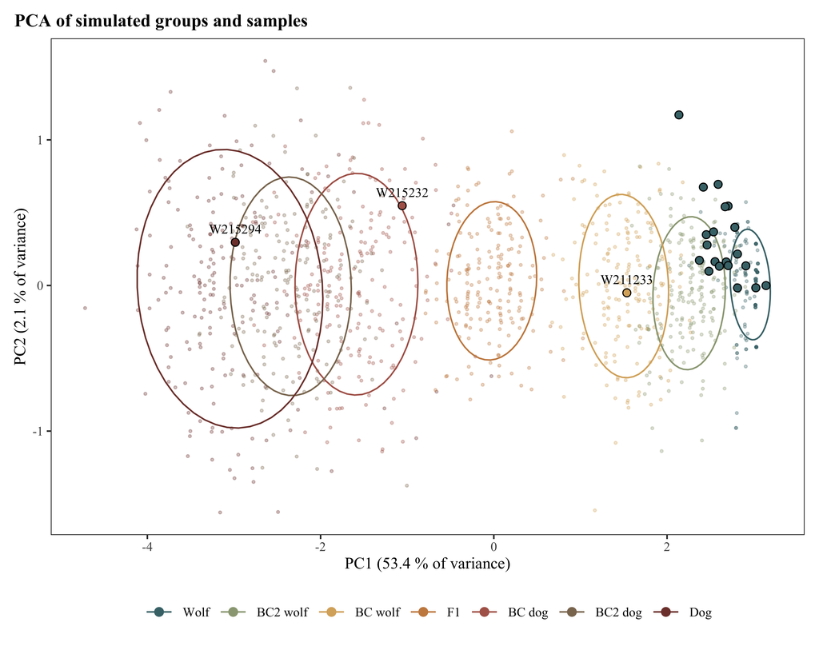

```r
### Plots with ggplot

# data prep, groups in order for the legend
simulated_levels <- c("Simulated wolf", "Simulated second backcross to wolf", "Simulated backcross to wolf", "Simulated F1",
                      "Simulated backcross to dog", "Simulated second backcross to dog", "Simulated dog")
simulated_short_labels <- c("Wolf", "BC2 wolf", "BC wolf", "F1", "BC dog", "BC2 dog", "Dog")
simulated_colours <- setNames(c("#467378", "#9AA582", "#D9AF6B", "#C98A4E", "#AF6458", "#8B775F", "#7E4038"), simulated_levels)

is_simulated <- animal_group %in% simulated_levels
simulated_factor <- factor(animal_group[is_simulated], levels = simulated_levels)
group_means <- tapply(pc_scores[is_simulated, 1], simulated_factor, mean) # mean of every simulated group

panel_theme <- theme_bw(base_family = plot_font, base_size = 9) +
  theme(panel.grid = element_blank(), plot.title = element_text(face = "bold", size = 10),
        plot.title.position = "plot", legend.position = "bottom", plot.margin = margin(8, 8, 8, 8))

simulated_scores <- data.frame(PC1 = pc_scores[is_simulated, 1], PC2 = pc_scores[is_simulated, 2],
                               group = factor(simulated_short_labels[as.integer(simulated_factor)], levels = simulated_short_labels))
short_colours <- setNames(simulated_colours, simulated_short_labels)

# Stan genotypes of the samples with their ancestry class from 05
stan_scores <- pca_scores %>%
  filter(group == "Stan genotypes") %>%
  mutate(sample = sub(" \\| .*", "", individual)) %>%
  left_join(transmute(stan_sample_parameters, sample = barcode, wolf_ancestry, wolf_ancestry_low, wolf_ancestry_high,
                      ancestry_class = case_when(wolf_ancestry >= 0.875 ~ "Wolf-like", wolf_ancestry >= 0.625 ~ "Backcross to wolf", wolf_ancestry >= 0.375 ~ "F1-like", wolf_ancestry >= 0.125 ~ "Backcross to dog", TRUE ~ "Dog-like")), by = "sample")

# candidates that arent wolf like
candidate_scores <- filter(stan_scores, ancestry_class != "Wolf-like")
pc1_label <- sprintf("PC1 (%.1f %% of variance)", variance_explained[1])

## 1. Plot , PC1 against PC2 with ellipses for the simulated groups, samples on top. Created in ggplot (all) so they can later be used with patchwork inside a panel. Tried it first with adegent own functions but it didnt look quite right

p_pca <- ggplot(simulated_scores, aes(PC1, PC2, colour = group)) +
  geom_point(size = 0.5, alpha = 0.3) +
  stat_ellipse(type = "norm", level = 0.675, linewidth = 0.4) +
  geom_point(data = stan_scores, aes(PC1, PC2), inherit.aes = FALSE, shape = 21, size = 1.8, colour = "black",
             fill = ancestry_class_colours[stan_scores$ancestry_class]) +
  geom_text(data = candidate_scores, aes(PC1, PC2, label = sample), inherit.aes = FALSE, vjust = -1, size = 2.6, family = plot_font) +
  scale_colour_manual(values = short_colours, name = NULL) +
  guides(colour = guide_legend(nrow = 1, override.aes = list(size = 2, alpha = 1))) +
  labs(title = "PCA of simulated groups and samples", x = pc1_label, y = sprintf("PC2 (%.1f %% of variance)", variance_explained[2])) +
  panel_theme

## 2. Plot, PC1 only with range of every simulated group as a box, samples as points in the top row, similar structure as before
pc1_rows <- c(simulated_short_labels, "Samples")
p_pc1 <- ggplot(simulated_scores, aes(PC1, factor(group, levels = pc1_rows), fill = group, colour = group)) +
  geom_boxplot(alpha = 0.4, outlier.shape = NA, width = 0.6) +
  geom_point(data = stan_scores, aes(PC1, factor("Samples", levels = pc1_rows)), inherit.aes = FALSE, shape = 21, size = 1.8, colour = "black", fill = ancestry_class_colours[stan_scores$ancestry_class], position = position_jitter(width = 0, height = 0.15, seed = 1)) +
  geom_text(data = candidate_scores, aes(PC1, factor("Samples", levels = pc1_rows), label = sample), inherit.aes = FALSE,
            vjust = -1.3, size = 2.6, family = plot_font) +
  scale_fill_manual(values = short_colours, guide = "none") + scale_colour_manual(values = short_colours, guide = "none") +
  scale_y_discrete(drop = FALSE) +
  labs(title = "PC1 of every simulated group and the samples", x = pc1_label, y = NULL) +
  panel_theme

## 3. Plot, agreement between my Stan ancestry measruments and PC1. Quick check if different methods describe the structure similary.
ancestry_correlation <- cor(stan_scores$wolf_ancestry, stan_scores$PC1)
p_ancestry <- ggplot(stan_scores, aes(wolf_ancestry, PC1)) +
  geom_hline(yintercept = group_means, colour = simulated_colours, linetype = "dotted") +
  geom_errorbar(aes(xmin = wolf_ancestry_low, xmax = wolf_ancestry_high), width = 0.15, orientation = "y", colour = "grey50") +
  geom_point(shape = 21, size = 1.8, colour = "black", fill = ancestry_class_colours[stan_scores$ancestry_class]) +
  geom_text(data = candidate_scores, aes(label = sample), vjust = -1, size = 2.6, family = plot_font) +
  annotate("text", x = 0, y = max(stan_scores$PC1), hjust = 0, size = 2.8, family = plot_font,
           label = sprintf("Pearson r = %.3f (%d samples)", ancestry_correlation, nrow(stan_scores))) +
  scale_x_continuous(limits = c(0, 1)) +
  scale_y_continuous(sec.axis = dup_axis(breaks = group_means, labels = simulated_short_labels, name = NULL)) +
  labs(title = "Stan wolf ancestry against PC1", x = "Wolf ancestry (05), mean and 95 % interval", y = pc1_label) +
  panel_theme

p_pca
```

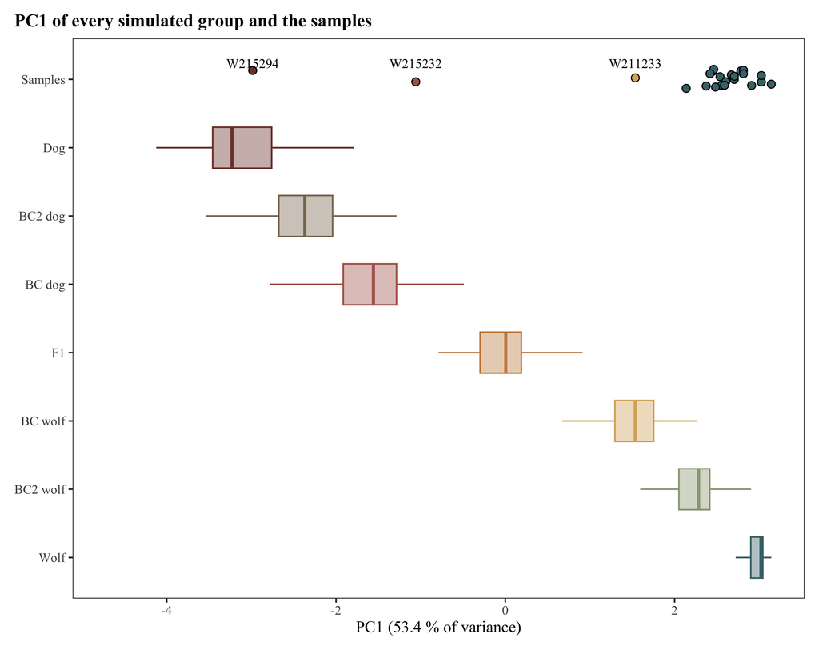

```r
p_pc1
```

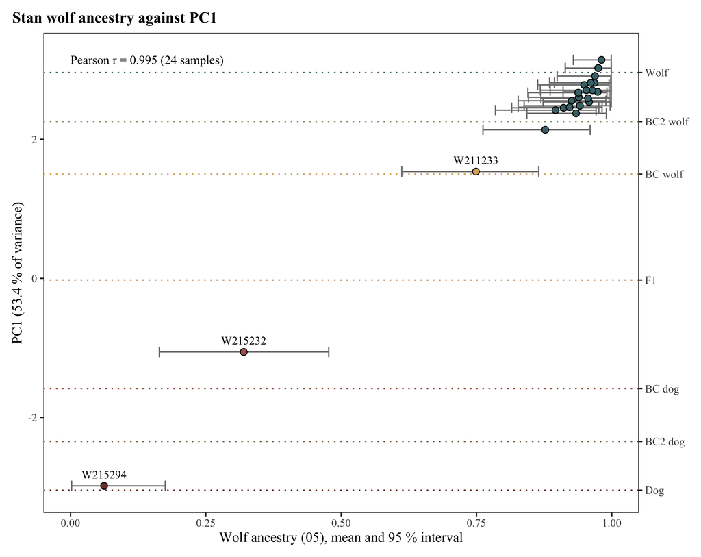

```r
p_ancestry
```

```r
ggsave(file.path(ancestry_out_dir, "pca_adegenet.png"), p_pca, width = 16, height = 12.7, units = "cm", dpi = 300, bg = "white")
ggsave(file.path(ancestry_out_dir, "pca_adegenet.pdf"), p_pca, width = 16, height = 12.7, units = "cm", device = cairo_pdf)
ggsave(file.path(ancestry_out_dir, "pca_pc1_only.png"), p_pc1, width = 16, height = 12.7, units = "cm", dpi = 300, bg = "white")
ggsave(file.path(ancestry_out_dir, "pca_pc1_only.pdf"), p_pc1, width = 16, height = 12.7, units = "cm", device = cairo_pdf)
ggsave(file.path(ancestry_out_dir, "pca_pc1_against_stan_ancestry.png"), p_ancestry, width = 16, height = 12.7, units = "cm", dpi = 300, bg = "white")
ggsave(file.path(ancestry_out_dir, "pca_pc1_against_stan_ancestry.pdf"), p_ancestry, width = 16, height = 12.7, units = "cm", device = cairo_pdf)
```

## 4 DAPC with the simulated groups as known classes

```r
# Number principal components kept, if there are too many it can look better seperated than it actually is
n_dapc_pca <- 10
# All the simulated animals for the training set, group is known
simulated_genind <- all_genind[which(is_simulated)]
pop(simulated_genind) <- simulated_factor
genotype_dapc <- dapc(simulated_genind, n.pca = n_dapc_pca, n.da = length(simulated_levels) - 1)

# This part cheks how many PC components DAPC should keep, before it was hard coded as 10, now its actually cross validated. from 1 to 20 it trains DAPC on a set of simualted animals, and tests on the rest.
simulated_allele_table <- tab(simulated_genind, freq = TRUE, NA.method = "mean") # converts to plain number table
set.seed(simulation_seed)

# cross validation, 30 random splits for each PC count, 10 % of animals for testing
dapc_cross_validation <- xvalDapc(simulated_allele_table, simulated_factor, n.pca = 1:20, n.rep = 30, training.set = 0.9, xval.plot = FALSE)
dapc_cross_validation_table <- data.frame(n_pca = as.integer(names(dapc_cross_validation$`Mean Successful Assignment by Number of PCs of PCA`)), correct_percent = 100 * dapc_cross_validation$`Mean Successful Assignment by Number of PCs of PCA`)

write_tsv(dapc_cross_validation_table, file.path(ancestry_out_dir, "dapc_cross_validation.tsv"))
kable(dapc_cross_validation_table, digits = 1, col.names = c("Principal components kept", "Correct assignment of held-back animals (%)"), caption = sprintf("DAPC cross-validation, best: %s PCs (used: %d)", dapc_cross_validation$`Number of PCs Achieving Highest Mean Success`, n_dapc_pca))
```

DAPC cross-validation, best: 1 PCs (used: 10)

| Principal components kept | Correct assignment of held-back animals (%) |
| --- | --- |
| 1 | 81.3 |
| 2 | 80.0 |
| 3 | 80.8 |
| 4 | 79.8 |
| 5 | 78.7 |
| 6 | 79.3 |
| 7 | 79.0 |
| 8 | 78.8 |
| 9 | 79.8 |
| 10 | 79.2 |
| 11 | 77.9 |
| 12 | 78.9 |
| 13 | 78.8 |
| 14 | 78.8 |
| 15 | 78.8 |
| 16 | 77.7 |
| 17 | 78.3 |
| 18 | 77.2 |
| 19 | 77.5 |
| 20 | 77.4 |

```r
# Share of simulated animals that are recognised as the same group from where they "come from"
kable(data.frame(group = names(summary(genotype_dapc)$assign.per.pop), correct_percent = 100 * summary(genotype_dapc)$assign.per.pop),
      digits = 1, col.names = c("Simulated group", "Assigned to own group (%)"), caption = "DAPC self-assignment of the simulated animals", row.names = FALSE)
```

DAPC self-assignment of the simulated animals

| Simulated group | Assigned to own group (%) |
| --- | --- |
| Simulated wolf | 97.8 |
| Simulated dog | 77.4 |
| Simulated F1 | 96.8 |
| Simulated backcross to wolf | 82.8 |
| Simulated backcross to dog | 72.0 |
| Simulated second backcross to wolf | 79.6 |
| Simulated second backcross to dog | 54.8 |

```r
# Membership probabilities of my 24 Stan (flat prior) genotypes samples
stan_rows <- which(animal_group == "Stan genotypes")
dapc_samples <- predict(genotype_dapc, newdata = all_genind[stan_rows])
dapc_membership <- data.frame(sample = sub(" \\| .*", "", indNames(all_genind)[stan_rows]),
                              assigned_group = as.character(dapc_samples$assign), # dapc class
                              highest_probability = apply(dapc_samples$posterior, 1, max), #probability of the class
                              round(dapc_samples$posterior, 3), check.names = FALSE)

# Table of seven probability columns per sample
write_tsv(dapc_membership, file.path(ancestry_out_dir, "dapc_sample_membership.tsv"))
kable(arrange(dapc_membership[, c("sample", "assigned_group", "highest_probability")], assigned_group), digits = 3,
      col.names = c("Sample", "DAPC group", "Membership probability"), row.names = FALSE)
```

| Sample | DAPC group | Membership probability |
| --- | --- | --- |
| W215232 | Simulated backcross to dog | 0.659 |
| W211233 | Simulated backcross to wolf | 0.778 |
| W215294 | Simulated dog | 0.846 |
| W215210.r1 | Simulated second backcross to wolf | 0.523 |
| W215273 | Simulated second backcross to wolf | 0.633 |
| W215539.r1 | Simulated second backcross to wolf | 0.538 |
| W211213 | Simulated wolf | 0.898 |
| W211224 | Simulated wolf | 0.847 |
| W211255 | Simulated wolf | 0.677 |
| W211287 | Simulated wolf | 0.791 |
| W211293 | Simulated wolf | 0.544 |
| W215154 | Simulated wolf | 0.808 |
| W215207.r1 | Simulated wolf | 0.859 |
| W215208.r1 | Simulated wolf | 0.689 |
| W215214 | Simulated wolf | 0.539 |
| W215214.r1 | Simulated wolf | 0.575 |
| W215217 | Simulated wolf | 0.847 |
| W215220 | Simulated wolf | 0.648 |
| W215220.r1 | Simulated wolf | 0.760 |
| W215222 | Simulated wolf | 0.670 |
| W215222.r1 | Simulated wolf | 0.604 |
| W215231 | Simulated wolf | 0.536 |
| W215511 | Simulated wolf | 0.501 |
| W215538 | Simulated wolf | 0.753 |

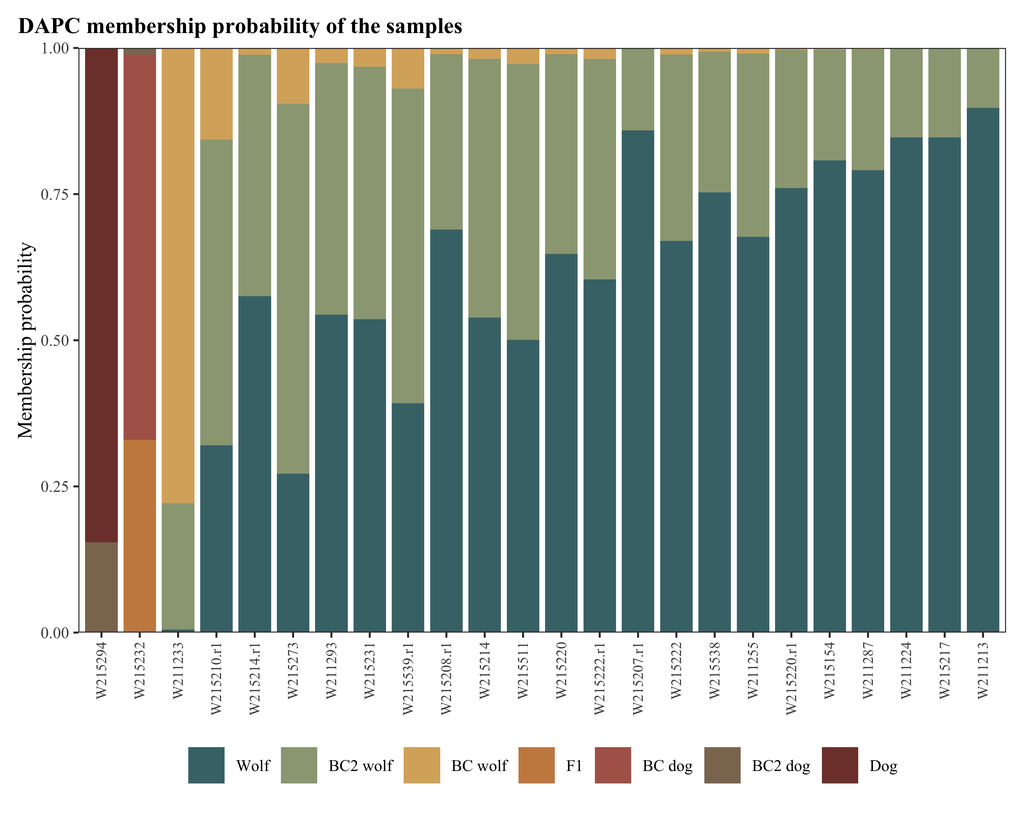

```r
# Membership probabilities as stacked barplot
dapc_order <- dapc_membership$sample[order(stan_scores$PC1[match(dapc_membership$sample, stan_scores$sample)])]
dapc_long <- data.frame(sample = rep(dapc_membership$sample, times = length(simulated_levels)),
                        group = rep(simulated_short_labels, each = nrow(dapc_membership)),
                        probability = as.vector(dapc_samples$posterior[, simulated_levels]))

p_dapc <- ggplot(dapc_long, aes(factor(sample, levels = dapc_order), probability, fill = factor(group, levels = simulated_short_labels))) +
  geom_col(width = 0.85, position = position_stack(reverse = TRUE)) +
  scale_fill_manual(values = short_colours, name = NULL) +
  scale_y_continuous(expand = c(0, 0)) +
  guides(fill = guide_legend(nrow = 1)) +
  labs(title = "DAPC membership probability of the samples", x = NULL, y = "Membership probability") +
  panel_theme + theme(axis.text.x = element_text(angle = 90, vjust = 0.5, hjust = 1, size = 6.5))

p_dapc
```

```r
ggsave(file.path(ancestry_out_dir, "dapc_membership.png"), p_dapc, width = 16, height = 12.7, units = "cm", dpi = 300, bg = "white")
ggsave(file.path(ancestry_out_dir, "dapc_membership.pdf"), p_dapc, width = 16, height = 12.7, units = "cm", device = cairo_pdf)
```

## 5 Ancestry analysis panel

```r
# Four plots combined into a panel using patchwork, tried it first with adegenet original plots but it looked wonky.
ancestry_panel <- (p_pca + labs(title = paste0("A   ", p_pca$labels$title))) +
  (p_pc1 + labs(title = paste0("B   ", p_pc1$labels$title))) +
  (p_ancestry + labs(title = paste0("C   ", p_ancestry$labels$title))) +
  (p_dapc + labs(title = paste0("D   ", p_dapc$labels$title)) + guides(fill = "none")) +
  plot_layout(ncol = 2, guides = "collect") & theme(legend.position = "bottom")
ancestry_panel
```

[figure not shown]

```r
ggsave(file.path(ancestry_out_dir, "ancestry_panel.png"), ancestry_panel, width = 29.7, height = 21, units = "cm", dpi = 300, bg = "white")
ggsave(file.path(ancestry_out_dir, "ancestry_panel.pdf"), ancestry_panel, width = 29.7, height = 21, units = "cm", device = cairo_pdf)
```

## 6 NewHybrids input data preparation

This chunk contains data prep for NewHybrids software with correct genotype codes per sample. It computes posterior probability for all six classes with Harmoinen et al (2021) research paper in mind. 100 simulated wolves and dogs are inputed as known pure parents (z0 for wolves, z1 for dogs). My samples use the flat prior as previious PCA analysis with same GQ cutoff.

Command used to run NewHybrids from the folder: `~/Tools/newhybrids/bin/OSX/newhybsng -d newhybrids_input.txt --burn-in 100000` `--num-sweeps 500000 --theta-prior Jeffreys --pi-prior Jeffreys -s 1 2 --no-gui`

```r
# Number of simulated wolves and dogs as pure parents, reference point for NewHybrids
n_newhybrids_reference <- 100

# New folder for NewHybrids inside ancestry analysis
newhybrids_dir <- file.path(ancestry_out_dir, "NewHybrids")
dir.create(newhybrids_dir, showWarnings = FALSE)

# Takes the wide sample table wtih sample rows by method and column as loci. stan genotypes used only in pca_loci order and turns it into matrix
stan_genotype_letters <- as.matrix(sample_table[sample_table$group == "Stan genotypes", pca_loci])

# Count copies of allele 1 and write the number insdie each cell (0, 1, 2) with the help of allele1_letters. Same trick as before.
allele1_letters <- matrix(rep(locus_alleles$allele1, each = nrow(stan_genotype_letters)), nrow = nrow(stan_genotype_letters))
sample_copies <- (substr(stan_genotype_letters, 1, 1) == allele1_letters) + (substr(stan_genotype_letters, 2, 2) == allele1_letters)

# Picks 100 refeerence animals from previously made 300 parent copies (wolves 1 -300, 301- 600 dogs ) and stack them
reference_copies <- parent_copies[c(1:n_newhybrids_reference, n_reference_wolves + 1:n_newhybrids_reference), ]
newhybrids_copies <- rbind(reference_copies, sample_copies)

# Turns the 0, 1, 2 number into NewHyibrids input codes.
newhybrids_genotypes <- ifelse(is.na(newhybrids_copies), "0", c("22", "12", "11")[newhybrids_copies + 1])
# Adds flags, z0 for known pure animal from popualtion 0 (wolf), z1 for pure dogs, "" unkown, what the software estimates
newhybrids_flags <- c(rep("z0", n_newhybrids_reference), rep("z1", n_newhybrids_reference), rep("", nrow(sample_copies)))
newhybrids_lines <- paste(seq_len(nrow(newhybrids_genotypes)), newhybrids_flags, apply(newhybrids_genotypes, 1, paste, collapse = " "))

# writes the file for NewHybrids
writeLines(c(paste("NumIndivs", nrow(newhybrids_genotypes)), paste("NumLoci", length(pca_loci)), "Digits 1", "Format Lumped", "",
             paste("LocusNames", paste(pca_loci, collapse = " ")), "", newhybrids_lines),
           file.path(newhybrids_dir, "newhybrids_input.txt"))

# Key to match the NewHybrids output rows back to the animals
newhybrids_key <- data.frame(index = seq_len(nrow(newhybrids_genotypes)), animal = c(paste("Simulated wolf", 1:n_newhybrids_reference), paste("Simulated dog", 1:n_newhybrids_reference), sub(" \\| .*", "", sample_table$individual[sample_table$group == "Stan genotypes"])),flag = newhybrids_flags)

write_tsv(newhybrids_key, file.path(newhybrids_dir, "newhybrids_key.tsv"))
```

## 7 NewHybrids power input data preparation

This part checks how sure you can be that the NewHybirds classification is correct, it test how much you can trust each class from my 24 samples. Same idea as in the Harmoinen et al. research paper. It saves into a separete folder, it tests 100 animals per 5 hybrid classes.

```r
# simulated hybrids per class as in referencer research paper
n_power_per_class <- 100
power_classes <- c("Simulated F1", "Simulated backcross to wolf", "Simulated backcross to dog",
                   "Simulated second backcross to wolf", "Simulated second backcross to dog")
# Output path
newhybrids_power_dir <- file.path(ancestry_out_dir, "NewHybrids_power")
dir.create(newhybrids_power_dir, showWarnings = FALSE)

# First 100 animals of every simulated hybrid class, copies of allele 1 read from the genind
power_rows <- unlist(lapply(power_classes, function(group_name) which(animal_group == group_name)[1:n_power_per_class]))
# Safety check my first run ran with only 50 animals accidentaly
stopifnot(!anyNA(power_rows))
power_copies <- tab(all_genind[power_rows])[, paste0(pca_loci, ".", locus_alleles$allele1)]


# Same reference wolves (z0) and dogs (z1) as in the previous run, same file prep
power_input_copies <- rbind(reference_copies, power_copies)
power_genotypes <- ifelse(is.na(power_input_copies), "0", c("22", "12", "11")[power_input_copies + 1])
power_flags <- c(rep("z0", n_newhybrids_reference), rep("z1", n_newhybrids_reference), rep("", nrow(power_copies)))
power_lines <- paste(seq_len(nrow(power_genotypes)), power_flags, apply(power_genotypes, 1, paste, collapse = " "))

writeLines(c(paste("NumIndivs", nrow(power_genotypes)), paste("NumLoci", length(pca_loci)), "Digits 1", "Format Lumped", "",
             paste("LocusNames", paste(pca_loci, collapse = " ")), "", power_lines),
           file.path(newhybrids_power_dir, "newhybrids_power_input.txt"))

# Key with the true class of every animal
power_key <- data.frame(index = seq_len(nrow(power_genotypes)),
                        true_class = c(rep("Simulated wolf", n_newhybrids_reference),
                                       rep("Simulated dog", n_newhybrids_reference), animal_group[power_rows]),
                        flag = power_flags)
write_tsv(power_key, file.path(newhybrids_power_dir, "newhybrids_power_key.tsv"))
```

## 8 NewHybrids power results

```r
# Class each simulated hybrid should get in NewHybrids. Second backcrosses grouped with backcrosses
power_expected_class <- c("Simulated F1" = "F1", "Simulated backcross to wolf" = "BC wolf", "Simulated backcross to dog" = "BC dog",
                          "Simulated second backcross to wolf" = "BC wolf", "Simulated second backcross to dog" = "BC dog")

newhybrids_classes <- c("Wolf", "Dog", "F1", "F2", "BC wolf", "BC dog")
# Reads the results, applies the true class from the key and filters for simulated hybrids
power_results <- read.table(file.path(newhybrids_power_dir, "aa-PofZ.txt"), skip = 1, col.names = c("index", "name", newhybrids_classes), check.names = FALSE) %>%
  left_join(power_key, by = "index") %>%
  filter(flag == "") %>%
  mutate(hybrid_probability = F1 + F2 + `BC wolf` + `BC dog`,
         power_class = factor(simulated_short_labels[match(true_class, simulated_levels)], levels = simulated_short_labels[2:6]))

# Expected probability each animal got the rigth class
power_results$expected_probability <- as.matrix(power_results[, newhybrids_classes])[cbind(seq_len(nrow(power_results)), match(power_expected_class[power_results$true_class], newhybrids_classes))]

# Share of correct class per simulated class
power_summary <- power_results %>%
  summarise(animals = n(), correct_percent = 100 * mean(expected_probability > 0.5), hybrid_percent = 100 * mean(hybrid_probability > 0.7), pure_percent = 100 * mean(pmax(Wolf, Dog) >= 0.5), .by = power_class) %>%
  arrange(power_class)

write_tsv(power_summary, file.path(newhybrids_power_dir, "newhybrids_power_summary.tsv"))
kable(power_summary, digits = 1, row.names = FALSE,
      col.names = c("Simulated class", "Animals", "Correct class (%, > 0.5)", "Recognised as hybrid (%, > 0.7)", "Assigned as pure wolf or dog (%)"), caption = "NewHybrids assignment of simulated hybrids of known class (33 loci, Jeffreys priors)")
```

NewHybrids assignment of simulated hybrids of known class (33 loci, Jeffreys priors)

| Simulated class | Animals | Correct class (%, > 0.5) | Recognised as hybrid (%, > 0.7) | Assigned as pure wolf or dog (%) |
| --- | --- | --- | --- | --- |
| BC2 wolf | 100 | 88 | 85 | 12 |
| BC wolf | 100 | 98 | 100 | 0 |
| F1 | 100 | 98 | 100 | 0 |
| BC dog | 100 | 79 | 72 | 21 |
| BC2 dog | 100 | 20 | 12 | 80 |

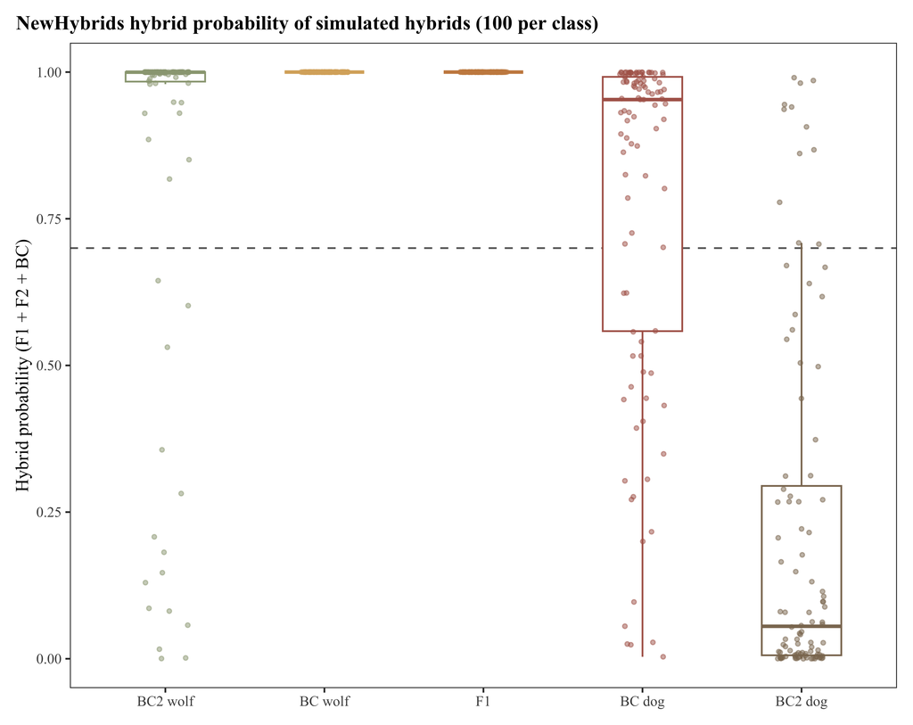

```r
# Hybrid probability for evey simulated hybrid in power analysis with 0.7 threshold (from reserach paper)
p_power <- ggplot(power_results, aes(power_class, hybrid_probability, colour = power_class)) +
  geom_hline(yintercept = 0.7, linetype = "dashed", colour = "grey40") +
  geom_boxplot(outlier.shape = NA, width = 0.5) +
  geom_point(size = 0.8, alpha = 0.5, position = position_jitter(width = 0.15, height = 0, seed = 1)) +
  scale_colour_manual(values = short_colours, guide = "none") +
  coord_cartesian(ylim = c(0, 1)) +
  labs(title = sprintf("NewHybrids hybrid probability of simulated hybrids (%d per class)", n_power_per_class),
       x = NULL, y = "Hybrid probability (F1 + F2 + BC)") +
  panel_theme

p_power
```

```r
ggsave(file.path(newhybrids_power_dir, "newhybrids_power.png"), p_power, width = 16, height = 12.7, units = "cm", dpi = 300, bg = "white")
ggsave(file.path(newhybrids_power_dir, "newhybrids_power.pdf"), p_power, width = 16, height = 12.7, units = "cm", device = cairo_pdf)
```

## 9 NewHybrids results visualizations

```r
# Names for columns with probabilites from result files
newhybrids_classes <- c("Wolf", "Dog", "F1", "F2", "BC wolf", "BC dog")

# Read results table and attaches the key made  in previous chunk and filters only for my 24 smaples
newhybrids_results <- read.table(file.path(newhybrids_dir, "aa-PofZ.txt"), skip = 1, col.names = c("index", "name", newhybrids_classes), check.names = FALSE) %>%
  left_join(newhybrids_key, by = "index") %>%
  filter(flag == "")

# For each sample it finds the most likely class and assigns the name
newhybrids_results$newhybrids_class <- newhybrids_classes[max.col(newhybrids_results[, newhybrids_classes], ties.method = "first")]

# saves probability of the most likely class, prob of being any hybrid and saves the decision from the Harmoinen assignment rules
newhybrids_results <- newhybrids_results %>%
  mutate(highest_probability = pmax(Wolf, Dog, F1, F2, `BC wolf`, `BC dog`),
         hybrid_probability = F1 + F2 + `BC wolf` + `BC dog`,
         harmoinen_call = case_when(hybrid_probability > 0.7 ~ "Hybrid",
                                    pmax(Wolf, Dog) >= 0.5 ~ "Pure",
                                    TRUE ~ "Unassigned"))

# Saves results
write_tsv(newhybrids_results, file.path(newhybrids_dir, "newhybrids_sample_classes.tsv"))
kable(arrange(newhybrids_results[, c("animal", "newhybrids_class", "highest_probability", "hybrid_probability", "harmoinen_call")], desc(hybrid_probability)), digits = 3, col.names = c("Sample", "NewHybrids class", "Probability", "Hybrid probability (F1 + F2 + BC)", "Call (Harmoinen et al. 2021)"))
```

| Sample | NewHybrids class | Probability | Hybrid probability (F1 + F2 + BC) | Call (Harmoinen et al. 2021) |
| --- | --- | --- | --- | --- |
| W211233 | BC wolf | 0.999 | 1.000 | Hybrid |
| W215232 | BC dog | 0.896 | 0.962 | Hybrid |
| W215210.r1 | Wolf | 0.986 | 0.014 | Pure |
| W211293 | Wolf | 0.998 | 0.002 | Pure |
| W215273 | Wolf | 0.999 | 0.001 | Pure |
| W215231 | Wolf | 0.999 | 0.001 | Pure |
| W215214 | Wolf | 1.000 | 0.000 | Pure |
| W215294 | Dog | 1.000 | 0.000 | Pure |
| W215222.r1 | Wolf | 1.000 | 0.000 | Pure |
| W211213 | Wolf | 1.000 | 0.000 | Pure |
| W211224 | Wolf | 1.000 | 0.000 | Pure |
| W211255 | Wolf | 1.000 | 0.000 | Pure |
| W211287 | Wolf | 1.000 | 0.000 | Pure |
| W215154 | Wolf | 1.000 | 0.000 | Pure |
| W215207.r1 | Wolf | 1.000 | 0.000 | Pure |
| W215208.r1 | Wolf | 1.000 | 0.000 | Pure |
| W215214.r1 | Wolf | 1.000 | 0.000 | Pure |
| W215217 | Wolf | 1.000 | 0.000 | Pure |
| W215220 | Wolf | 1.000 | 0.000 | Pure |
| W215220.r1 | Wolf | 1.000 | 0.000 | Pure |
| W215222 | Wolf | 1.000 | 0.000 | Pure |
| W215511 | Wolf | 1.000 | 0.000 | Pure |
| W215538 | Wolf | 1.000 | 0.000 | Pure |
| W215539.r1 | Wolf | 1.000 | 0.000 | Pure |

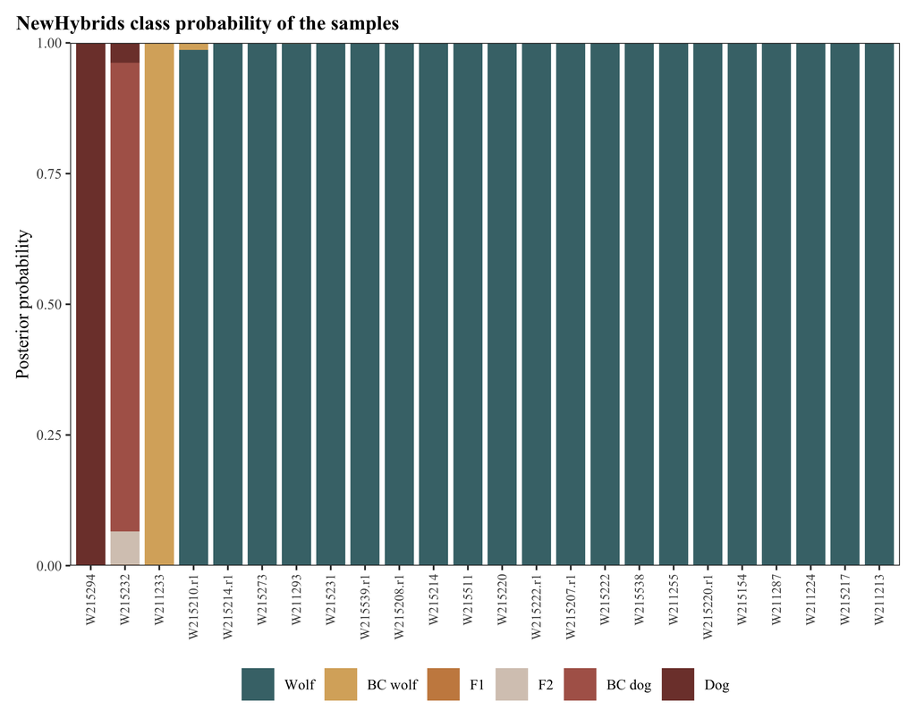

```r
# Same plot as DAPC
newhybrids_plot_order <- c("Wolf", "BC wolf", "F1", "F2", "BC dog", "Dog")
newhybrids_colours <- setNames(c("#467378", "#D9AF6B", "#C98A4E", "#D7C9BE", "#AF6458", "#7E4038"), newhybrids_plot_order)
newhybrids_long <- newhybrids_results %>%
  select(sample = animal, all_of(newhybrids_classes)) %>%
  pivot_longer(-sample, names_to = "group", values_to = "probability")

p_newhybrids <- ggplot(newhybrids_long, aes(factor(sample, levels = dapc_order), probability, fill = factor(group, levels = newhybrids_plot_order))) +
  geom_col(width = 0.85, position = position_stack(reverse = TRUE)) +
  scale_fill_manual(values = newhybrids_colours, name = NULL) +
  scale_y_continuous(expand = c(0, 0)) +
  guides(fill = guide_legend(nrow = 1)) +
  labs(title = "NewHybrids class probability of the samples", x = NULL, y = "Posterior probability") +
  panel_theme + theme(axis.text.x = element_text(angle = 90, vjust = 0.5, hjust = 1, size = 6.5))

p_newhybrids
```

```r
ggsave(file.path(newhybrids_dir, "newhybrids_classes.png"), p_newhybrids, width = 16, height = 12.7, units = "cm", dpi = 300, bg = "white")
ggsave(file.path(newhybrids_dir, "newhybrids_classes.pdf"), p_newhybrids, width = 16, height = 12.7, units = "cm", device = cairo_pdf)
```

## 10 STRUCTURE input data preparation

This chunk contains input data prep for STRUCTURE analysis. Specific allele strucutre input for all 33 loci and mainparams and extraparams file with mainly defualt values except for settings which are relavant to analysis from Harmoinen et al. Run with admixutre model, correlated allele freq, 50000 burn in and 500000 repetitions, and 95 % interval (ANCESTPINT) so its later comparable to my Bayesian ancestry run, two clusters (k = 2, for wolf and dog) with fixed seed.

Command for running STRUCTURE:

`for run in 1 2 3 4 5; do` `~/Tools/structure/structure_kernel_src/structure -m mainparams -e extraparams` `-K 2 -D $run -o structure_K2_run$run > log_run$run.txt &` `done; wait`

```r
# New output paths for STRUCTURE
structure_dir <- file.path(ancestry_out_dir, "STRUCTURE")
dir.create(structure_dir, showWarnings = FALSE)

# All the parent animals and samples combined (186 reference wolves and dogs and 24 samples)
structure_copies <- rbind(parent_copies, sample_copies)
# Makes names for reference animals wolf_1 to wolf_186 and so on, my samples keep id
structure_labels <- c(paste0("wolf_", seq_len(n_reference_wolves)), paste0("dog_", seq_len(n_reference_dogs)), newhybrids_key$animal[newhybrids_key$flag == ""])
# Makes 1 (wolf), 2 (dog), 3 (sample) labels for STR
structure_population <- rep(1:3, c(n_reference_wolves, n_reference_dogs, nrow(sample_copies)))

# Converts it into allele input type for STRUCTURE (if to copies of allele 1, then its converted to 1 meaning HM for allele 1)
first_allele <- ifelse(is.na(structure_copies), -9, ifelse(structure_copies >= 1, 1, 2))
second_allele <- ifelse(is.na(structure_copies), -9, ifelse(structure_copies == 2, 1, 2))

# Binds two column for both alleles per locus in pca_loci order
structure_alleles <- cbind(first_allele, second_allele)[, order(rep(seq_along(pca_loci), 2))]

# writes input file for STRUCTURE with header names
writeLines(c(paste(pca_loci, collapse = " "), paste(structure_labels, structure_population, apply(structure_alleles, 1, paste, collapse = " "))), file.path(structure_dir, "structure_input.txt"))

# Same settings as in Harmoinen et al. run with admixutre model, correlated allele freq, 50000 burn in and 500000 repetitions, and 95 % interval (ANCESTPINT) so its later comparable to my Bayesian ancestry run, two clusters (k = 2, for wolf and dog) with fixed seed. All other param are mainly defualts.
structure_mainparams <- c(MAXPOPS = "2", BURNIN = "50000", NUMREPS = "500000", INFILE = "structure_input.txt",
                          OUTFILE = "structure_output", NUMINDS = nrow(structure_alleles), NUMLOCI = length(pca_loci),
                          PLOIDY = "2", MISSING = "-9", ONEROWPERIND = "1", LABEL = "1", POPDATA = "1", POPFLAG = "0",
                          LOCDATA = "0", PHENOTYPE = "0", EXTRACOLS = "0", MARKERNAMES = "1", RECESSIVEALLELES = "0",
                          MAPDISTANCES = "0", PHASED = "0", PHASEINFO = "0", MARKOVPHASE = "0", NOTAMBIGUOUS = "-999")

structure_extraparams <- c(NOADMIX = "0", LINKAGE = "0", USEPOPINFO = "0", LOCPRIOR = "0", FREQSCORR = "1", ONEFST = "0",
                           INFERALPHA = "1", POPALPHAS = "0", ALPHA = "1.0", INFERLAMBDA = "0", POPSPECIFICLAMBDA = "0",
                           LAMBDA = "1.0", FPRIORMEAN = "0.01", FPRIORSD = "0.05", UNIFPRIORALPHA = "1", ALPHAMAX = "10.0",
                           ALPHAPRIORA = "1.0", ALPHAPRIORB = "2.0", LOG10RMIN = "-4.0", LOG10RMAX = "1.0", LOG10RPROPSD = "0.1",
                           LOG10RSTART = "-2.0", GENSBACK = "2", MIGRPRIOR = "0.01", PFROMPOPFLAGONLY = "0", LOCISPOP = "0",
                           LOCPRIORINIT = "1.0", MAXLOCPRIOR = "20.0", PRINTNET = "1", PRINTLAMBDA = "1", PRINTQSUM = "1",
                           SITEBYSITE = "0", PRINTQHAT = "0", UPDATEFREQ = "10000", PRINTLIKES = "0", INTERMEDSAVE = "0",
                           ECHODATA = "1", ANCESTDIST = "1", NUMBOXES = "1000", ANCESTPINT = "0.95", COMPUTEPROB = "1",
                           ADMBURNIN = "500", ALPHAPROPSD = "0.025", STARTATPOPINFO = "0", RANDOMIZE = "0", SEED = "1",
                           METROFREQ = "10", REPORTHITRATE = "0")
# Saves params for STR
writeLines(paste("#define", names(structure_mainparams), structure_mainparams), file.path(structure_dir, "mainparams"))
writeLines(paste("#define", names(structure_extraparams), structure_extraparams), file.path(structure_dir, "extraparams"))
```

## 11 STRUCTURE Results

This chunk prepares STRUCTURE results, makes a couple of plots and compares it with my Bayesian ancestry run results.

```r
#Reads all output files from structure saves full full path fo read lines later
structure_files <- list.files(structure_dir, pattern = "^structure_K2_run[0-9]+_f$", full.names = TRUE)

# Running function once per file, reads the lines, one row per animal, finds labels, % of loci missing, population, q for both cluster and lower and upper limit of the 95 % interval, also and attaches file name
structure_runs <- bind_rows(lapply(structure_files, function(file_name) {
  readLines(file_name, warn = FALSE) %>%
    grep("\\([0-9]+\\)\\s+[0-9]+\\s+:", ., value = TRUE) %>%
    gsub("[(),:]", " ", .) %>%
    read.table(text = ., col.names = c("number", "label", "missing", "population", paste0("X", 1:6))) %>%
    mutate(run = basename(file_name))
}))

# This part solves the label swtiching from STRUCTURE, it doesn't know which one is wolf just assigns 1 or 0. Based on that is saves the right q and right lower and upper limits.
structure_runs <- structure_runs %>%
  mutate(wolf_is_cluster_1 = mean(X1[startsWith(label, "wolf_")]) > 0.5, .by = run) %>%
  transmute(run, label, structure_q = ifelse(wolf_is_cluster_1, X1, X2),
            structure_low = ifelse(wolf_is_cluster_1, X3, X5), structure_high = ifelse(wolf_is_cluster_1, X4, X6))

# Mean over the runs as in the referenced paper, grouped by label
structure_summary <- structure_runs %>%
  summarise(run_sd = sd(structure_q), runs = n(), structure_q = mean(structure_q), structure_low = mean(structure_low),
            structure_high = mean(structure_high), .by = label) %>%
  mutate(group = factor(case_when(startsWith(label, "wolf_") ~ "Reference wolves",
                                  startsWith(label, "dog_") ~ "Reference dogs",
                                  TRUE ~ "Samples"), levels = c("Reference wolves", "Samples", "Reference dogs")))

# Simple ummary table grouped by group (smaples, dogs, wolves)
structure_groups <- summarise(structure_summary, animals = n(), mean_q = mean(structure_q), lowest_q = min(structure_q), highest_q = max(structure_q), .by = group)

kable(structure_groups, digits = 3, col.names = c("Group", "Animals", "Mean wolf q", "Lowest", "Highest"),
      caption = sprintf("STRUCTURE wolf q (K = 2, mean of %d runs)", length(structure_files)))
```

STRUCTURE wolf q (K = 2, mean of 5 runs)

| Group | Animals | Mean wolf q | Lowest | Highest |
| --- | --- | --- | --- | --- |
| Reference wolves | 186 | 0.997 | 0.964 | 0.999 |
| Reference dogs | 186 | 0.030 | 0.001 | 0.514 |
| Samples | 24 | 0.904 | 0.005 | 0.999 |

```r
# COmbines results for 24 samples with my Bayesian ancestry run results
structure_samples <- structure_summary %>%
  inner_join(select(stan_scores, sample, wolf_ancestry), by = c("label" = "sample")) %>%
  select(sample = label, structure_q, structure_low, structure_high, run_sd, wolf_ancestry) %>%
  arrange(structure_q)

write_tsv(structure_samples, file.path(structure_dir, "structure_sample_q.tsv"))

# Summary table for html
structure_sample_table <- structure_samples %>%
  mutate(structure = sprintf("%.3f (%.3f-%.3f)", structure_q, structure_low, structure_high)) %>%
  select(sample, structure, run_sd, wolf_ancestry)

kable(structure_sample_table, digits = 3,
      col.names = c("Sample", "STRUCTURE wolf q (95 % interval)", "SD between runs", "Bayesian wolf ancestry (05)"),
      caption = sprintf("STRUCTURE and Bayesian wolf ancestry, Pearson r = %.3f", cor(structure_samples$structure_q, structure_samples$wolf_ancestry)))
```

STRUCTURE and Bayesian wolf ancestry, Pearson r = 0.999

| Sample | STRUCTURE wolf q (95 % interval) | SD between runs | Bayesian wolf ancestry (05) |
| --- | --- | --- | --- |
| W215294 | 0.005 (0.000-0.070) | 0.000 | 0.062 |
| W215232 | 0.328 (0.165-0.493) | 0.000 | 0.320 |
| W211233 | 0.770 (0.634-0.882) | 0.000 | 0.749 |
| W215210.r1 | 0.898 (0.783-0.977) | 0.001 | 0.877 |
| W211293 | 0.931 (0.835-0.993) | 0.001 | 0.911 |
| W215273 | 0.939 (0.829-1.000) | 0.001 | 0.896 |
| W215231 | 0.945 (0.856-0.994) | 0.000 | 0.922 |
| W215214 | 0.957 (0.866-1.000) | 0.000 | 0.926 |
| W215222.r1 | 0.975 (0.899-1.000) | 0.000 | 0.938 |
| W215214.r1 | 0.979 (0.889-1.000) | 0.000 | 0.934 |
| W211255 | 0.991 (0.933-1.000) | 0.000 | 0.949 |
| W215220 | 0.996 (0.957-1.000) | 0.000 | 0.939 |
| W215538 | 0.997 (0.961-1.000) | 0.000 | 0.953 |
| W215539.r1 | 0.997 (0.966-1.000) | 0.000 | 0.941 |
| W215208.r1 | 0.998 (0.978-1.000) | 0.000 | 0.958 |
| W215220.r1 | 0.998 (0.971-1.000) | 0.000 | 0.961 |
| W215511 | 0.998 (0.976-1.000) | 0.000 | 0.956 |
| W211213 | 0.999 (0.991-1.000) | 0.000 | 0.981 |
| W211224 | 0.999 (0.990-1.000) | 0.000 | 0.975 |
| W211287 | 0.999 (0.984-1.000) | 0.000 | 0.969 |
| W215154 | 0.999 (0.984-1.000) | 0.000 | 0.968 |
| W215207.r1 | 0.999 (0.987-1.000) | 0.000 | 0.974 |
| W215217 | 0.999 (0.990-1.000) | 0.000 | 0.975 |
| W215222 | 0.999 (0.984-1.000) | 0.000 | 0.964 |

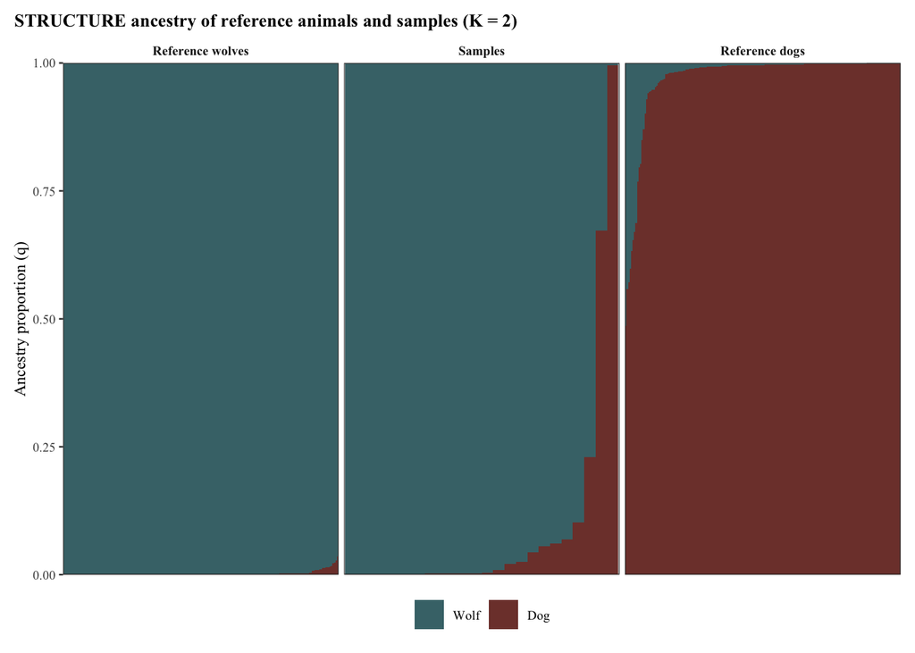

```r
### 1. Plot, same classic stacked bar plot for STRUCTURE, faceted by group
structure_order <- structure_summary$label[order(structure_summary$group, -structure_summary$structure_q)]
structure_long <- bind_rows(transmute(structure_summary, label, group, part = "Wolf", q = structure_q),
                            transmute(structure_summary, label, group, part = "Dog", q = 1 - structure_q))

p_structure_bars <- ggplot(structure_long, aes(factor(label, levels = structure_order), q, fill = factor(part, levels = c("Wolf", "Dog")))) +
  geom_col(width = 1) +
  facet_grid(~ group, scales = "free_x") +
  scale_fill_manual(values = short_colours[c("Wolf", "Dog")], name = NULL) +
  scale_y_continuous(expand = c(0, 0)) +
  labs(title = "STRUCTURE ancestry of reference animals and samples (K = 2)", x = NULL, y = "Ancestry proportion (q)") +
  panel_theme +
  theme(axis.text.x = element_blank(), axis.ticks.x = element_blank(), panel.spacing = unit(3, "pt"),
                      strip.background = element_blank(), strip.text = element_text(face = "bold"))
p_structure_bars
```

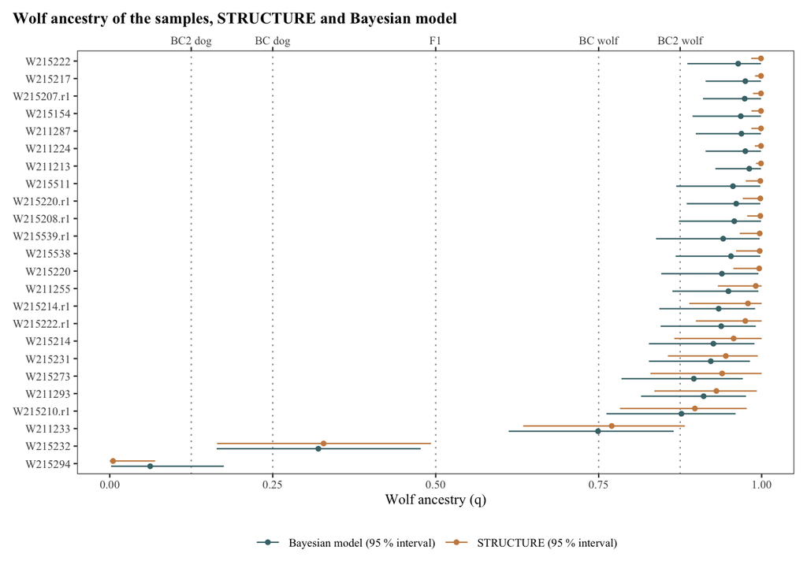

```r
ggsave(file.path(structure_dir, "structure_barplot.png"), p_structure_bars, width = 16, height = 8, units = "cm", dpi = 300, bg = "white")
ggsave(file.path(structure_dir, "structure_barplot.pdf"), p_structure_bars, width = 16, height = 8, units = "cm", device = cairo_pdf)

### 2. Plot , wolf q from Bayes and STRUCTURE runs with error bars
sample_q <- bind_rows(transmute(structure_samples, sample, method = "STRUCTURE (95 % interval)", q = structure_q, low = structure_low, high = structure_high), transmute(stan_scores, sample, method = "Bayesian model (95 % interval)", q = wolf_ancestry, low = wolf_ancestry_low, high = wolf_ancestry_high))

p_structure_samples <- ggplot(sample_q, aes(q, factor(sample, levels = structure_samples$sample), colour = method)) +
  geom_vline(xintercept = c(0.125, 0.25, 0.5, 0.75, 0.875), linetype = "dotted", colour = "grey60") +
  geom_pointrange(aes(xmin = low, xmax = high), size = 0.15, position = position_dodge(width = 0.6)) +
  scale_x_continuous(limits = c(0, 1), sec.axis = dup_axis(breaks = c(0.125, 0.25, 0.5, 0.75, 0.875), labels = c("BC2 dog", "BC dog", "F1", "BC wolf", "BC2 wolf"), name = NULL)) +
  scale_colour_manual(values = c("#467378", "#C98A4E"), name = NULL) +
  labs(title = "Wolf ancestry of the samples, STRUCTURE and Bayesian model", x = "Wolf ancestry (q)", y = NULL) +
  panel_theme
p_structure_samples
```

```r
ggsave(file.path(structure_dir, "structure_sample_q.png"), p_structure_samples, width = 16, height = 12.7, units = "cm", dpi = 300, bg = "white")
ggsave(file.path(structure_dir, "structure_sample_q.pdf"), p_structure_samples, width = 16, height = 12.7, units = "cm", device = cairo_pdf)
```

## 12 Combined ancestry results

This chunk produces a dataframe, side by side result for every sample using all the different methods which makes results easibly comparable. MEthods in question are my measured wolf ancestry from the Bayesian model, PC1, DAPC and NewHybrids,

```r
# Creates combined classed for DAPC, adds probabilites per sample and class and keeps the maximum value
dapc_combined <- dapc_long %>%
  mutate(dapc_class = case_when(group %in% c("Wolf", "BC2 wolf") ~ "Wolf-like",
                                group %in% c("Dog", "BC2 dog") ~ "Dog-like",
                                TRUE ~ group)) %>%
  summarise(dapc_probability = round(sum(probability), 3), .by = c(sample, dapc_class)) %>%
  slice_max(dapc_probability, n = 1, by = sample, with_ties = FALSE)

# Prepares one row per sample with column of different ancestry results, Stan ancestry, PC1, DAPC and NewHybrids ordered by PC1
ancestry_summary <- stan_scores %>%
  select(sample, wolf_ancestry, wolf_ancestry_low, wolf_ancestry_high, ancestry_class, PC1) %>%
  left_join(dapc_combined, by = "sample") %>%
  left_join(transmute(newhybrids_results, sample = animal, newhybrids_class, newhybrids_probability = highest_probability,
                      newhybrids_hybrid_probability = hybrid_probability, harmoinen_call), by = "sample") %>%
  arrange(PC1)
write_tsv(ancestry_summary, file.path(ancestry_out_dir, "ancestry_summary.tsv"))

kable(transmute(ancestry_summary, sample,
                wolf_ancestry = sprintf("%.2f (%.2f-%.2f)", wolf_ancestry, wolf_ancestry_low, wolf_ancestry_high),
                ancestry_class,
                PC1 = sprintf("%.2f", PC1),
                dapc = sprintf("%s (%.2f)", dapc_class, dapc_probability),
                newhybrids = sprintf("%s (%.3f)", newhybrids_class, newhybrids_probability),
                harmoinen_call),
      col.names = c("Sample", "Wolf ancestry (95 % interval)", "Bayesian class", "PC1", "DAPC class (probability)",
                    "NewHybrids class (probability)", "Call (Harmoinen et al. 2021)"),
      caption = "Ancestry of every sample with all methods, ordered by PC1")
```

Ancestry of every sample with all methods, ordered by PC1

| Sample | Wolf ancestry (95 % interval) | Bayesian class | PC1 | DAPC class (probability) | NewHybrids class (probability) | Call (Harmoinen et al. 2021) |
| --- | --- | --- | --- | --- | --- | --- |
| W215294 | 0.06 (0.00-0.17) | Dog-like | -2.99 | Dog-like (1.00) | Dog (1.000) | Pure |
| W215232 | 0.32 (0.16-0.48) | Backcross to dog | -1.06 | BC dog (0.66) | BC dog (0.896) | Hybrid |
| W211233 | 0.75 (0.61-0.86) | Backcross to wolf | 1.54 | BC wolf (0.78) | BC wolf (0.999) | Hybrid |
| W215210.r1 | 0.88 (0.76-0.96) | Wolf-like | 2.14 | Wolf-like (0.84) | Wolf (0.986) | Pure |
| W215214.r1 | 0.93 (0.84-0.99) | Wolf-like | 2.37 | Wolf-like (0.99) | Wolf (1.000) | Pure |
| W215273 | 0.90 (0.79-0.97) | Wolf-like | 2.42 | Wolf-like (0.90) | Wolf (0.999) | Pure |
| W211293 | 0.91 (0.81-0.98) | Wolf-like | 2.45 | Wolf-like (0.97) | Wolf (0.998) | Pure |
| W215231 | 0.92 (0.83-0.98) | Wolf-like | 2.46 | Wolf-like (0.97) | Wolf (0.999) | Pure |
| W215539.r1 | 0.94 (0.84-1.00) | Wolf-like | 2.48 | Wolf-like (0.93) | Wolf (1.000) | Pure |
| W215208.r1 | 0.96 (0.87-1.00) | Wolf-like | 2.54 | Wolf-like (0.99) | Wolf (1.000) | Pure |
| W215214 | 0.93 (0.83-0.99) | Wolf-like | 2.55 | Wolf-like (0.98) | Wolf (1.000) | Pure |
| W215511 | 0.96 (0.87-1.00) | Wolf-like | 2.59 | Wolf-like (0.97) | Wolf (1.000) | Pure |
| W215220 | 0.94 (0.85-0.99) | Wolf-like | 2.60 | Wolf-like (0.99) | Wolf (1.000) | Pure |
| W215222.r1 | 0.94 (0.84-0.99) | Wolf-like | 2.67 | Wolf-like (0.98) | Wolf (1.000) | Pure |
| W215207.r1 | 0.97 (0.91-1.00) | Wolf-like | 2.68 | Wolf-like (1.00) | Wolf (1.000) | Pure |
| W215222 | 0.96 (0.89-1.00) | Wolf-like | 2.70 | Wolf-like (0.99) | Wolf (1.000) | Pure |
| W215538 | 0.95 (0.87-1.00) | Wolf-like | 2.71 | Wolf-like (0.99) | Wolf (1.000) | Pure |
| W211255 | 0.95 (0.86-0.99) | Wolf-like | 2.78 | Wolf-like (0.99) | Wolf (1.000) | Pure |
| W215220.r1 | 0.96 (0.89-1.00) | Wolf-like | 2.81 | Wolf-like (1.00) | Wolf (1.000) | Pure |
| W215154 | 0.97 (0.89-1.00) | Wolf-like | 2.81 | Wolf-like (1.00) | Wolf (1.000) | Pure |
| W211287 | 0.97 (0.90-1.00) | Wolf-like | 2.91 | Wolf-like (1.00) | Wolf (1.000) | Pure |
| W211224 | 0.97 (0.91-1.00) | Wolf-like | 3.02 | Wolf-like (1.00) | Wolf (1.000) | Pure |
| W215217 | 0.97 (0.91-1.00) | Wolf-like | 3.02 | Wolf-like (1.00) | Wolf (1.000) | Pure |
| W211213 | 0.98 (0.93-1.00) | Wolf-like | 3.14 | Wolf-like (1.00) | Wolf (1.000) | Pure |

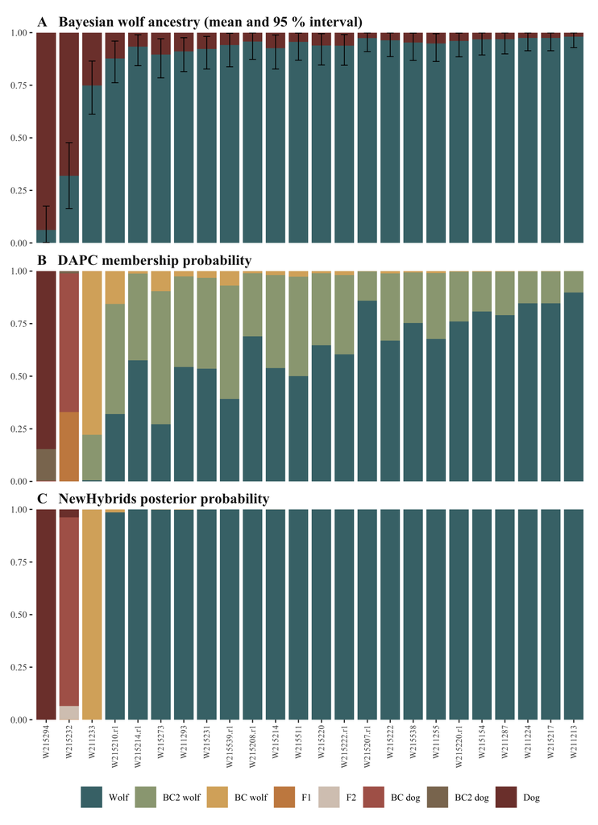

```r
# One long table with all three methods, sample, class, probability (or ancestry share) and method
bar_methods <- c("A   Bayesian wolf ancestry (mean and 95 % interval)", "B   DAPC membership probability", "C   NewHybrids posterior probability")
bar_data <- bind_rows(transmute(stan_scores, sample, group = "Wolf", probability = wolf_ancestry,
                                low = wolf_ancestry_low, high = wolf_ancestry_high, method = bar_methods[1]),
  transmute(stan_scores, sample, group = "Dog", probability = 1 - wolf_ancestry, method = bar_methods[1]),
  mutate(dapc_long, method = bar_methods[2]),
  mutate(newhybrids_long, method = bar_methods[3])) %>%
  mutate(sample = factor(sample, levels = dapc_order), group = factor(group, levels = append(simulated_short_labels, "F2", after = 4)))

# Stacked bar plots per method ordered and same colours (Bayesian ancestry, DAPC and NewHybrids)
p_ancestry_bars <- ggplot(bar_data, aes(sample, probability, fill = group)) +
  geom_col(width = 0.85, position = position_stack(reverse = TRUE)) +
  geom_errorbar(aes(ymin = low, ymax = high), width = 0.3, linewidth = 0.3, na.rm = TRUE) +
  facet_wrap(~ method, ncol = 1) +
  scale_fill_manual(values = c(short_colours, F2 = "#D7C9BE"), name = NULL) +
  scale_y_continuous(expand = c(0, 0)) +
  guides(fill = guide_legend(nrow = 1)) +
  labs(x = NULL, y = NULL) +
  panel_theme + theme(axis.text.x = element_text(angle = 90, vjust = 0.5, hjust = 1, size = 6.5),
                      strip.background = element_blank(), strip.text = element_text(face = "bold", hjust = 0, size = 11),
                      panel.border = element_blank())

p_ancestry_bars
```

```r
ggsave(file.path(ancestry_out_dir, "ancestry_bar_panel.png"), p_ancestry_bars, width = 16, height = 22, units = "cm", dpi = 300, bg = "white")
ggsave(file.path(ancestry_out_dir, "ancestry_bar_panel.pdf"), p_ancestry_bars, width = 16, height = 22, units = "cm", device = cairo_pdf)

# Agreement table for replicate samples.
replicate_pairs <- ancestry_summary %>%
  mutate(animal = sub("\\.r1$", "", sample)) %>%
  filter(n() > 1, .by = animal)
kable(select(replicate_pairs, animal, sample, wolf_ancestry, dapc_class, newhybrids_class, harmoinen_call), digits = 2,
      col.names = c("Animal", "Sample", "Wolf ancestry", "DAPC class", "NewHybrids class", "Call"), caption = "Ancestry of replicate samples of the same animal")
```

Ancestry of replicate samples of the same animal

| Animal | Sample | Wolf ancestry | DAPC class | NewHybrids class | Call |
| --- | --- | --- | --- | --- | --- |
| W215214 | W215214.r1 | 0.93 | Wolf-like | Wolf | Pure |
| W215214 | W215214 | 0.93 | Wolf-like | Wolf | Pure |
| W215220 | W215220 | 0.94 | Wolf-like | Wolf | Pure |
| W215222 | W215222.r1 | 0.94 | Wolf-like | Wolf | Pure |
| W215222 | W215222 | 0.96 | Wolf-like | Wolf | Pure |
| W215220 | W215220.r1 | 0.96 | Wolf-like | Wolf | Pure |

**Settings used for this run**

| Setting | Value |
| --- | --- |
| run_date | 2026-11-04 22:28 |
| dataset_name | big |
| primer_panel_path | Data/Supporting_data/Primer_panels/12864_2021_7761_MOESM12_ESM_filtered.xlsx |
| input_type | unpadded |
| use_anchors | TRUE |
| anchor_length | 3 |
| probe_type | asp_primers |
| threshold_type | errors |
| min_score_fraction | 0.65 |
| error_rate | 0.08 |
| prior_type | ancestry |
| prior_het_share | 0.15 |
| prior_population | FreqWOLF_EastEurope |
| prior_floor | 0.001 |
| ancestry_prior_shape | 1 |
| phi_hom_structure | shared |
| genotype_prior_type | flat |
| gq_cutoff | 20 |
| reference_source | real |
| reference_ped_path | Data/Supporting_data/Reference_populations/GTIC-D-20-00312R1.ped |
| reference_map_path | Data/Supporting_data/Reference_populations/GTIC-D-20-00312R1.map |
| reference_wolf_groups | wolGer, wolRom, wolFin, wolRus |
| reference_dog_groups | dog_Illumina, dog_nonpedigree |
| wolf_frequency_column | FreqWOLF_EastEurope |
| dog_frequency_column | FreqDOG |
| n_reference_wolves | 186 |
| n_reference_dogs | 186 |
| n_simulated_per_hybrid_class | 186 |
| simulation_seed | 1 |